# Definição de prioris e resumo da posteriori

### Fernando Mayer

### 2019-09-05

# Análise bayesiana de dados

A análise de dados sob a perspectiva Bayesiana resume-se à 3 etapas:
1. Definir a distribuição *à priori*
  - Informativa
  - Não informativa
2. Definir a função de verossimilhança
3. Encontrar a distribuição posterior
  - Famílias conjugadas
  - Simulação estocástica

#### Todo processo de inferência será baseado na distribuição posterior

# Distribuições posteriores

### Famílias conjugadas

- As **famílias conjugadas** podem ser utilizadas quando o
produto `\(\pi(\theta) \cdot f(\mathbf{x}|\theta)\)` possui **forma fechada**,
ou seja, resulta em uma distribuição conhecida
- Portanto, a posterior é obtida diretamente pelo teorema de Bayes
  - `\(\uparrow\)` Resultado simples e conveniente
  - `\(\downarrow\)` Restringe a escolha das distribuições *priori* e de
verossimilhança

#### Definição: família conjugada

Seja `\(\mathcal{F}\)` uma família de distribuições para a
verossimilhança `\(f(\mathbf{x}|\theta)\)`, e `\(\mathcal{P}\)` uma família de
distribuição para a *priori* `\(\pi(\theta)\)`. Dizemos que
`\(\mathcal{F}\)` e `\(\mathcal{P}\)` são **famílias conjugadas** de
distribuições se a distribuição posterior `\(\pi(\theta|\mathbf{x})\)` também for
um membro de `\(\mathcal{P}\)`.

# Distribuições posteriores

### Famílias conjugadas

Exemplo: Beta-binomial com `\(\pi(\theta) \sim Beta(\alpha, \beta)\)` e
`\(f(\mathbf{x}|\theta) \sim Bin(n, \theta)\)`

$$
`\begin{align*}
\pi(\theta|\mathbf{x}) &\propto {\pi(\theta)} \cdot {f(\mathbf{x}|\theta)} \\
&\propto
{\frac{\Gamma{(\alpha+\beta)}}{\Gamma{(\alpha)}\Gamma{(\beta)}}
\theta^{\alpha-1} (1-\theta)^{\beta-1}} \cdot
{\binom{n}{x} \theta^x (1-\theta)^{n-x}}\\
&\propto \theta^{\alpha+x-1} (1-\theta)^{\beta+n-x-1}
\end{align*}`
$$

Portanto,
`\(\pi(\theta|\mathbf{x}) \sim Beta(\alpha^* = \alpha+x, \beta^* = \beta + n - x)\)`

# Distribuições posteriores

### Simulação estocástica

- A **simulação estocástica** é necessária quando o produto
`\(\pi(\theta) \cdot f(\mathbf{x}|\theta)\)` não possui forma fechada, e resulta
em uma distribuição desconhecida
- Portanto é necessário realizar um processo de simulação para se
construir a posterior
  - `\(\uparrow\)` Aplicação não se restringe apenas às famílias
conjugadas
  - `\(\downarrow\)` O processo de simulação pode ser muito "caro"
computacionalmente
- Alguns métodos de simulação:
  - Monte Carlo via Cadeias de Markov (MCMC)
  - Re-amostragem por importância
- Outros: *Integrated Nested Laplace Approximation* - INLA

# Distribuições posteriores

Independente de como a posterior foi obtida:

- É um compromisso entre a *priori* (que carrega o **conhecimento
prévio**), e a verossimilhança (que expressa o **conhecimento atual**
adquirido com o experimento realizado)
- Representa todo o conhecimento existente sobre o problema, portanto a
inferência Bayesiana é baseada nesta distribuição

> "A posterior de hoje é a *priori* de amanhã"

# Inferência

#### Abordagem clássica

- `\(\theta\)` é uma quantidade **desconhecida**, mas **fixa**
- Uma amostra aleatória `\(\mathbf{x} = (x_1, x_2, \ldots, x_n)\)` é obtida a
partir de uma população indexada por `\(\theta\)`
- Com base nos valores observados na amostra, o conhecimento
sobre `\(\theta\)` é obtido

#### Abordagem Bayesiana

- `\(\theta\)` é uma quantidade **desconhecida**, e **aleatória**
- A variabilidade em `\(\theta\)` é expressa pela *priori* `\(\pi(\theta)\)`
- Uma amostra aleatória `\(\mathbf{x} = (x_1, x_2, ..., x_n)\)` é obtida a
partir de uma população indexada por `\(\theta\)`
- A distribuição **a priori** é **atualizada** com
essa informação da amostra, representada pela verossimilhança
`\(f(\mathbf{x}|\theta)\)`

# Estimação por intervalo

#### Abordagem clássica

- Dizemos que o intervalo aleatório `\((T_1, T_2)\)`,
`\(T_1(\mathbf{X}) \leq T_2(\mathbf{X})\)`,
é um **intervalo de confiança** para `\(\theta\)`, com
coeficiente de confiança `\(\gamma = 1-\alpha\,, (0 < \alpha < 1)\)`,
se
$$
P[T_1 < \theta < T_2] = \gamma
$$
- Notação:
$$
\text{IC}(\theta,\gamma\%) = (T_1, T_2)
$$
- O intervalo **contém** `\(\theta\)` com probabilidade `\(\gamma\)`
- Uma vez que o parâmetro é fixo, o intervalo é aleatório
- `\(\theta \in (T_1, T_2)\)` com probabilidade 0 ou 1

# Estimação por intervalo

#### Abordagem clássica

Visualização de 100 intervalos de confiança

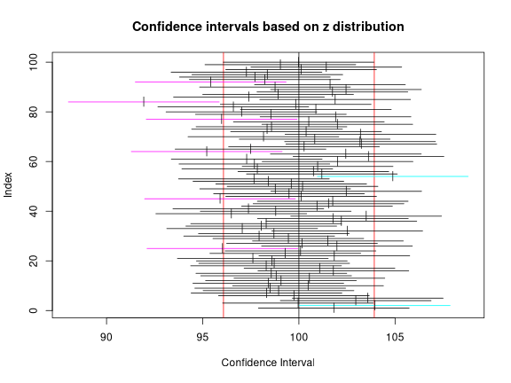

```r
require(TeachingDemos)
ci.examp(reps = 100)
```

# Estimação por intervalo

#### Abordagem Bayesiana

- Chamamos de **intervalo de credibilidade** de
`\(\gamma = 1-\alpha\)`, `\((0 < \alpha < 1)\)`, o intervalo delimitado pelos
percentis `\([\alpha/2]\)` e `\([1 - (\alpha/2)]\)`
$$
`\begin{align*}
(\theta_{[\alpha/2]}, \theta_{[1-(\alpha/2)]})
\end{align*}`
$$
da distribuição posterior `\(\pi(\theta|\mathbf{x})\)` para `\(\theta\)`.
- De maneira mais geral, dizemos que `\((T_1,T_2)\)`,
`\(T_1 = \theta_{[\alpha/2]}\)` e `\(T_2 = \theta_{[1-(\alpha/2)]}\)`, é um
intervalo de credibilidade para `\(\theta\)` com coeficiente de
confiança `\(\gamma\)` se
$$
\int_{T_1}^{T_2} \pi(\theta|\mathbf{x}) d\theta = \gamma
$$
- Notação:
$$
`\begin{align*}
\text{ICr}(\theta,\gamma\%) = (\theta_{[\alpha/2]},
\theta_{[1-(\alpha/2)]})
\end{align*}`
$$
- Um **intervalo de credibilidade** é então o intervalo de
valores mais prováveis de `\(\theta\)`, que soma probabilidade
`\(\gamma\)`
- `\(\theta \in (\theta_{[\alpha/2]},\theta_{[1-(\alpha/2)]})\)` com
probabilidade `\(\gamma\)`

# Estimação por intervalo

### Interpretação

- **Abordagem clássica**: Temos `\(\gamma\%\)` de confiança de
que o intervalo contém `\(\theta\)`.
- **Abordagem Bayesiana**: Temos `\(\gamma\%\)` de confiança de
que `\(\theta\)` pertence a esse intervalo.

# Estimação por intervalo

### Exemplo (Kinas e Andrade, 2010)

**Interesse**: média de baleias avistadas em 10 milhas
náuticas (MN)
  - Em 150 MN navegadas foram realizadas 10 avistagens
  - Obter a distribuição posterior `\(\pi(\theta|\mathbf{x})\)` para o
  número médio de baleias avistadas

Caracterização do problema:

$$
`\begin{align*}
x &\equiv \text{número de avistagens} = 10 \\
n &\equiv \text{número de unidades amostradas} = 150/10 = 15 \\
\theta &\equiv \text{número médio de avistagens/10 MN}
\end{align*}`
$$

```r
# Número de avistagens
x <- 10
# Unidades amostradas
n <- 15
# Possiveis valores para teta (numero médio de avistagens)
teta <- seq(0, 2, length = 200)
```

# Estimação por intervalo

### Exemplo

Suposições do problema:

$$
`\begin{align*}
f(\mathbf{x}|\theta) &\sim Poisson(n\theta) \\
\pi(\theta) &\sim Gama(\alpha,\beta) \\
\pi(\theta|\mathbf{x}) &\sim \, ?
\end{align*}`
$$

Posterior conjugada para `\(\pi(\theta) \sim Gama(\alpha,\beta)\)` e
`\(f(\mathbf{x}|\theta) \sim Poisson(n\theta)\)`:

$$
`\begin{align*}
\pi(\theta|\mathbf{x}) &\propto {\pi(\theta)} \cdot {f(\mathbf{x}|\theta)} \\
&\propto {\frac{\beta^{\alpha}}{\Gamma(\alpha)}
\theta^{\alpha-1} \text{e}^{-\beta \theta}} \cdot
{\frac{n^x}{x!} \theta^x \text{e}^{-n\theta}} \\
&\propto \theta^{\alpha+x-1} \text{e}^{-\theta(\beta+n)}
\end{align*}`
$$

Portanto
$$
`\begin{align*}
\pi(\theta|\mathbf{x}) \sim Gama(\alpha^* = \alpha+x, \beta^* = \beta+n)
\end{align*}`
$$

# Estimação por intervalo

Considerando que não existe nenhuma informação prévia sobre `\(\theta\)`,
vamos assumir que `\(\pi(\theta)\)` é uma *priori* não informativa, por
exemplo `\(\theta \sim Gama(\alpha = 1, \beta = 0.1)\)`

```r
alfa <- 1
beta <- 0.1
## Calcula a densidade da priori
priori.ni <- dgamma(teta, alfa, beta)
```

Assim, os parâmetros da posterior
`\(\pi(\theta|\mathbf{x}) \sim Gama(\alpha^* = \alpha+x, \beta^*=\beta+n)\)`

```r
(alfa.star <- alfa + x)
# [1] 11
(beta.star <- beta + n)
# [1] 15.1
```

# Estimação por intervalo

Cálculo da densidade da posterior com os novos parâmetros

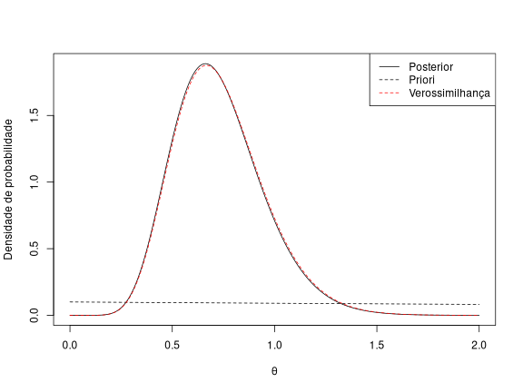

```r
post.ni <- dgamma(teta, alfa.star, beta.star)
plot(teta, post.ni, type = "l", xlab = expression(theta),
     ylab = "Densidade de probabilidade")
lines(teta, priori.ni, lty = 2)
lines(teta, dgamma(teta, 1 + x, n), col = 2, lty = 2)
legend("topright",  lty = c(1, 2, 2), col = c(1, 1, 2),
       legend = c("Posterior", "Priori", "Verossimilhança"))
```

# Estimação por intervalo

A partir da posterior `\(Gama(\alpha^*, \beta^*)\)` , podemos encontrar um
**intervalo de credibilidade** de
`\(\gamma = 1-\alpha = 1 - 0.05 = 0.95 = 95\%\)`, onde os intervalos serão
delimitados pelos percentis
$$
`\begin{align*}
(\theta_{[0.025]}, \theta_{[0.975]})
\end{align*}`
$$
da posterior `\(\pi(\theta|\mathbf{x})\)`

```r
qgamma(c(0.025, 0.975), alfa.star, beta.star)
# [1] 0.363653 1.217904
```

# Estimação por intervalo

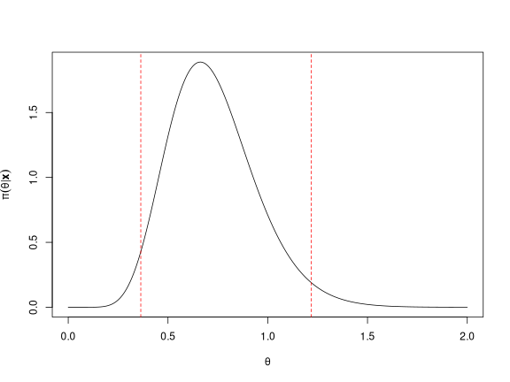

```r
## Gráfico da posterior com intervalo de credibilidade
plot(teta, post.ni, type = "l", xlab = expression(theta),
     ylab = expression(pi(paste(theta, "|", bold(x)))))
abline(v = qgamma(c(0.025, 0.975), alfa.star, beta.star),
       lty = 2, col = 2)
```

# Estimação por intervalo

Considere que artigos científicos indicam que na região de estudo
deve-se esperar uma média de 0.45 avistagens/10 MN. Podemos utilizar
essa informação como uma *priori* **informativa**.
- Igualando essa informação à esperança da Gama:
$$
E(X) = \frac{\alpha}{\beta} = 0.45 \quad \Rightarrow \quad \beta =
\frac{\alpha}{0.45}
$$
- Como a *priori* deve ser informativa, podemos assumir um
valor relativamente alto para `\(\alpha\)`, p.ex. `\(\alpha=4.5\)`
$$
\beta = \frac{\alpha}{0.45} = \frac{4.5}{0.45} = 10
$$
- Portanto ficamos com uma *priori* informativa
`\(\pi(\theta) \sim Gama(\alpha = 4.5, \beta = 10)\)`

```r
alfa.i <- 4.5
beta.i <- 10
## Calcula a densidade da priori
priori.i <- dgamma(teta, alfa.i, beta.i)
```

# Estimação por intervalo

A posterior
`\(\pi(\theta|\mathbf{x}) \sim Gama(\alpha^* =\alpha+x,\beta^*=\beta+n)\)`

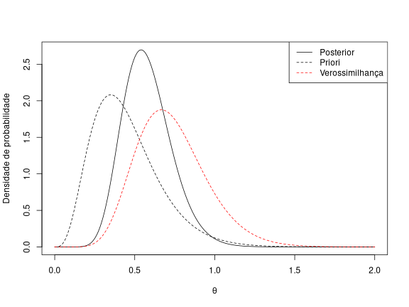

```r
alfa.star.i <- alfa.i + x
beta.star.i <- beta.i + n
## Cálculo da densidade da posterior com a priori informativa
post.i <- dgamma(teta, alfa.star.i, beta.star.i)
# Visualização
plot(teta, post.i, type = "l", xlab = expression(theta),
     ylab = "Densidade de probabilidade")
lines(teta, priori.i, lty = 2)
lines(teta, dgamma(teta, 1 + x, n), col = 2, lty = 2)
legend("topright",  lty = c(1, 2, 2), col = c(1, 1, 2),
       legend = c("Posterior", "Priori", "Verossimilhança"))
```

# Estimação por intervalo

Podemos encontrar o **intervalo de credibilidade**

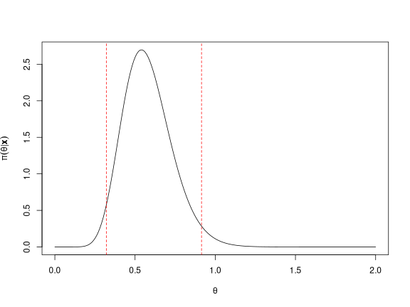

```r
qgamma(c(0.025, 0.975), alfa.star.i, beta.star.i)
# [1] 0.3209414 0.9144457
## Gráfico da posterior com intervalo de credibilidade
plot(teta, post.i, type = "l", xlab = expression(theta),
     ylab = expression(pi(paste(theta, "|", bold(x)))))
abline(v = qgamma(c(0.025, 0.975), alfa.star.i, beta.star.i),
       lty = 2, col = 2)
```

# Estimação por intervalo

Um resumo simples das duas posteriores obtidas

```r
## Inferência com a priori não informativa
qgamma(c(.025, .5, .975), alfa.star, beta.star)
# [1] 0.3636530 0.7065247 1.2179044
## Inferência com a priori informativa
qgamma(c(.025, .5, .975), alfa.star.i, beta.star.i)
# [1] 0.3209414 0.5667225 0.9144457
```

# Estimação por intervalo

Comparação das duas posteriores

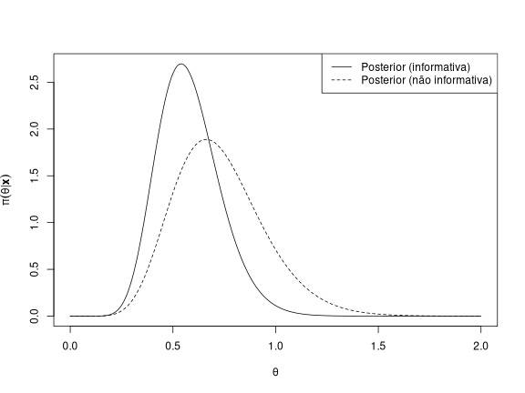

```r
plot(teta, post.i, type = "l", xlab = expression(theta),
     ylab = expression(pi(paste(theta, "|", bold(x)))))
lines(teta, post.ni, lty = 2)
legend("topright",
       legend = c("Posterior (informativa)",
                  "Posterior (não informativa)"), lty = c(1,2))
```

# Outro exemplo

Seja `\(x_1, \ldots, x_n\)` uma a.a. de uma distribuição normal de média `\(\mu\)`
conhecida e variância `\(\sigma^2\)` desconhecida. Considere a priori
`\([\sigma^2] \propto 1/\sigma^2\)`.

1. Obtenha a expressão da verossimilhança do modelo.
2. Obtenha a expressão da distribuição a posteriori.
3. É possível identificar a posteriori do modelo como alguma distribuição
conhecida?
4. Considere que foi tomada a amostra dada pelos valores a seguir, e que
`\(\mu = 10\)`. Obtenha a expressão da posteriori.

```
# [1] 12.1  8.7 11.3  9.2 10.5  9.7 11.6
```

5. Indique (com comandos do R ou de alguma outra forma) como resumos
pontuais e intervalares desta distribuição a posteriori poderiam ser
obtidos para fins de inferência

# Priori de Jeffreys

O que significa `\([\sigma^2] \propto 1/\sigma^2\)`?

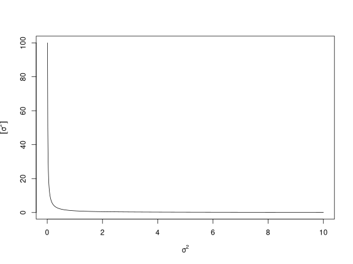

```r
x <- seq(0, 10, 0.01)
fx <- 1/x
plot(x, fx, type = "l",
     xlab = expression(sigma^2),
     ylab = expression(group("[", paste(sigma^2), "]")))
```

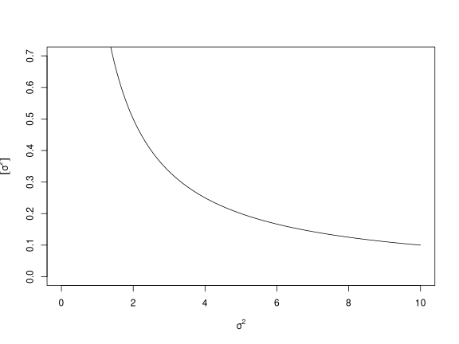

```r
x <- seq(0, 10, 0.01)
fx <- 1/x
plot(x, fx, type = "l",
     xlab = expression(sigma^2),
*    ylim = c(0,  0.7),
     ylab = expression(group("[", paste(sigma^2), "]")))
```

# 1. Expressão da verossimilhança

As funções de verossimilhança `\(L(\sigma^2)\)`, log-verossimilhança
`\(l(\sigma^2)\)`, escore `\(U(\sigma^2)\)` e hessiana `\(H(\sigma^2)\)` são dadas
por:

$$
`\begin{align*}
L(\sigma^2; y) &= \prod_{i=1}^n \frac{1}{\sqrt{2\pi\sigma^2}}
                  \exp\left\{-\frac{1}{2\sigma^2}(y_i - \mu)^2\right\} \\
&= (2\pi)^{-n/2} (\sigma^2)^{-n/2} \exp\left\{-\frac{1}{2\sigma^2}\sum_{1=1}^n(y_i - \mu)^2\right\} \\
l(\sigma^2; y) = \log\{L(\sigma^2; y)\} &=
(-n/2) \left[ \log(2\pi) + \log(\sigma^2) + \frac{\sum_{1=1}^n(y_i -
\mu)^2}{n} (\sigma^2)^{-1} \right] \\
U(\sigma^2) = \frac{{\rm d} l(\sigma^2; y)}{{\rm d}\sigma^2} &=
(-n/2) [(\sigma^2)^{-1} - \frac{\sum_{1=1}^n(y_i - \mu)^2}{n} (\sigma^2)^{-2}] \\
H(\sigma^2) = \frac{{\rm d}^2 l(\sigma^2; y)}{{\rm d}(\sigma^2)^2} &=
(-n/2) [-(\sigma^2)^{-2} + \frac{\sum_{1=1}^n(y_i - \mu)^2}{n} (\sigma^2)^{-3}]
\end{align*}`
$$

# 2. Expressão da distribuição posterior

A expressão da distribuição a posteriori é obtida da forma:

$$
`\begin{align*}
[\sigma^2|y] &\propto [\sigma^2] \cdot L(\sigma^2; y) \\
 &= (\sigma^2)^{-1} \cdot (2\pi)^{-n/2} (\sigma^2)^{-n/2}
 \exp\left\{-\frac{1}{2\sigma^2}\sum_{1=1}^n(y_i - \mu)^2\right\} \\
 &\propto (\sigma^2)^{-(n/2) - 1} \exp\left\{-\frac{\sum_{1=1}^n(y_i -
 \mu)^2}{2\sigma^2}\right\}
\end{align*}`
$$

É possível identificar esta posteriori como alguma distribuição
conhecida?

# 3. Identificar a posteriori como alguma distribuição conhecida

Posterior:

$$
`\begin{align*}
[\sigma^2|y] \propto (\sigma^2)^{-(n/2) - 1}
\exp\left\{ -\frac{\sum_{1=1}^n (y_i - \mu)^2}{2\sigma^2} \right\}
\end{align*}`
$$

`\(X \sim {\rm Gama}(\alpha, \beta)\)`

$$
f(x; \alpha, \beta) = \frac{1}{\beta^\alpha \Gamma(\alpha)} \;
x^{\alpha-1} \; \exp \{-x/\beta\} \; \mathbb{I}_{x\geq0}
$$
$$
E[X] = \alpha \beta \qquad Var[X] = \alpha \beta^2
$$

`\(X \sim {\rm IGama}(\alpha, \beta)\)`

$$
f(x; \alpha, \beta) = \frac{1}{\beta^\alpha \Gamma(\alpha)} \;
x^{-\alpha-1} \; \exp\{-1/(\beta x)\} \; \mathbb{I}_{x\geq0}
$$
$$
E[X] = \frac{1}{\beta(\alpha-1)} \qquad
Var[X] = \frac{1}{\beta^2(\alpha-1)^2 (\alpha-2)}
$$

# 3. Identificar a posteriori como alguma distribuição conhecida

A expressão
$$
`\begin{align*}
[\sigma^2|y] \propto (\sigma^2)^{-(n/2) - 1}
\exp\left\{ -\frac{\sum_{1=1}^n (y_i - \mu)^2}{2\sigma^2} \right\}
\end{align*}`
$$
vista como uma função de `\(\sigma^2\)`, corresponde ao núcleo de uma
densidade *gama inversa* de parâmetros:
$$
\alpha = \frac{n}{2} \qquad \text{ e } \qquad
\beta = \frac{2}{\sum_{1=1}^n(y_i - \mu)^2}
$$

Esta distribuição também é chamada na literatura de *qui-quadrado
inversa escalonada*.

# 4. Expressão da posteriori para os dados

Para o conjunto de dados temos que

$$
\alpha = \frac{n}{2} = \frac{7}{2} = 3,5 \qquad \text{ e } \qquad
\beta = \frac{2}{\sum_{1=1}^n(y_i - \mu)^2} =  \frac{2}{11,33} = 0,1765
$$

```r
y <- c(12.1, 8.7, 11.3, 9.2, 10.5, 9.7, 11.6)
(a.post <- length(y)/2)
# [1] 3.5
(b.post <- 2/sum((y - 10)^2))
# [1] 0.1765225
```

Embora códigos para tal distribuição possam ser obtidos já
implementados,  vamos definindo
uma função da densidade gama-inversa a partir de sua expressão.
A seguir usamos a função para obter o gráfico da posteriori obtida aqui.

```r
dinvgamma <- function(x, a, b, log = FALSE){
    res <- ifelse(
        x > 0,
        - a * log(b) - log(gamma(a)) - (a+1)*log(x) - 1/(b*x), -Inf)
    if(!log) res <- exp(res)
    return(res)
}
```

# 4. Expressão da posteriori para os dados

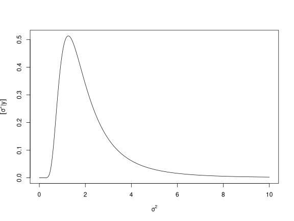

```r
curve(dinvgamma(x, a = a.post, b = b.post), from = 0, to = 10, n = 501,
      xlab = expression(sigma^2),
      ylab = expression(group("[", paste(sigma^2,"|",y), "]")))
```

# 5. Resumos pontuais e intervalares

### Resumos pontuais: média da posteior

Neste caso se tem a expressão analítica, que portanto deve ser
utilizada.
- Como em muitos casos pode não ser disponível, ilustra-se também a
obtenção por integração numérica e por simulação.

- Expressão analítica
$$
E[\sigma^2|y] = \frac{1}{\beta(\alpha-1)} =
2.27
$$

```r
(e.post <- 1/(b.post * (a.post - 1)))
# [1] 2.266
```

- Integração numérica (a partir da definição de esperança de uma v.a.).
$$
E[\sigma^2|y] = \int_0^{\infty} \sigma^2 f(\sigma^2|y){\rm d}\sigma^2
$$

```r
Epost <- function(par, ...) par * dinvgamma(par, ..., log = FALSE)
integrate(Epost, lower = 0, upper = 50, a = a.post, b = b.post)
# 2.263282 with absolute error < 6.6e-06
```

# 5. Resumos pontuais e intervalares

### Resumos pontuais: média da posteior

- Por simulação

Se `\(X \sim {\rm Gama}(\alpha, \beta)\)` então
`\(Y = 1/X \sim {\rm IGama}(\alpha, \beta)\)`.

Portanto, para simular de uma distribuição gama inversa basta tomar o
inverso de valores simulados de uma distribuição gama com os os mesmos
parâmetros.

```r
set.seed(123)
sim <- 1/rgamma(10000, shape = a.post, scale = b.post)
hist(sim, prob = TRUE, ylim = c(0,0.5),
     breaks = c(seq(0, 10, by = 0.5), seq(10, 60, by = 2)),
     xlab = expression(sigma^2),
     ylab = expression(group("[", paste(sigma^2,"|",y), "]")),
     main = "", xlim = c(0, 10))
lines(density(sim))
curve(dinvgamma(x, a = a.post, b = b.post), from = 0.01, to = 30,
      add = TRUE, col = 3, n = 501)
```

# 5. Resumos pontuais e intervalares

### Resumos pontuais: média da posteior

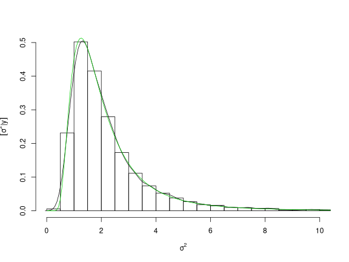

```r
mean(sim)
# [1] 2.280075
```

# 5. Resumos pontuais e intervalares

### Resumos pontuais: moda da posteior

Assim como no caso da média, a expressão analítica da moda é conhecida
mas ilustra-se também a obtenção por otimização numérica e por
simulação.
- Expressão analítica
$$
Mo[\sigma^2|y] = \frac{1}{\beta(\alpha+1)} =
1.26
$$

```r
(mo.post <- 1/(b.post * (a.post + 1)))
# [1] 1.258889
```

- Otimização numérica, maximizando a densidade

```r
optimize(dinvgamma, lower = 0, upper = 50, a = a.post, b = b.post,
         log = FALSE, maximum = TRUE)$maximum
# [1] 1.258905
```

- Simulação. Utiliza-se aqui um algorítmo simples tomando-se o ponto de
máximo de uma suavização da densidade

```r
sim.den <- density(sim, n = 1024)
sim.den$x[which.max(sim.den$y)]
# [1] 1.32702
```

# 5. Resumos pontuais e intervalares

### Resumos pontuais: mediana da posteior

- Expressão analítica: não disponível
- Otimização numérica: usando inversos dos quantis da distribuição gama

```r
(md.post <- 1/qgamma(1 - 0.5, shape = a.post, scale = b.post))
# [1] 1.78543
```

- Simulação

```r
median(sim)
# [1] 1.793622
```

# 5. Resumos pontuais e intervalares

### Resumos pontuais: média, moda e mediana

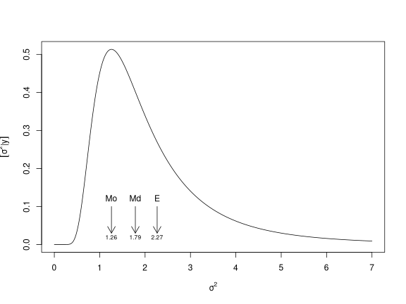

# 5. Resumos pontuais e intervalares

### Resumos intervalares: intervalos de credibilidade

- Expressão analítica: não disponível
- Por otimização numérica. Podemos definir uma função específica para a
gama-inversa:

```r
qinvgamma <- function(p, a, b, ...) {
    1/qgamma(1 - p, shape = a, scale = b, ...)
}
(ICq <- qinvgamma(c(0.025, 0.975), a = a.post, b = b.post))
# [1] 0.7075605 6.7046610
```

- Por simulação

```r
quantile(sim, prob = c(0.025, 0.975))
#      2.5%     97.5%
# 0.7075484 6.8346235
```

# 5. Resumos pontuais e intervalares

### Resumos intervalares: HPD

- Quando a distribuição posterior e assimétrica, o intervalo de
credibilidade nem sempre representa a porção central da distribuição
adequadamente
- Por isso, usamos o intervalo HPD (*Highest Posterior Density*), que,
por definição, sempre será o menor intervalo possível (central)

```r
library(HDInterval)
(IChpd <- hdi(sim))
#     lower     upper
# 0.4796374 5.3586471
# attr(,"credMass")
# [1] 0.95
```

Veja a diferença:

```r
ICq
# [1] 0.7075605 6.7046610
diff(ICq)
# [1] 5.9971
IChpd
# [1] 0.4796374 5.3586471
diff(IChpd)
# [1] 4.87901
```

# 5. Resumos pontuais e intervalares

### Resumos intervalares: quantis x HPD

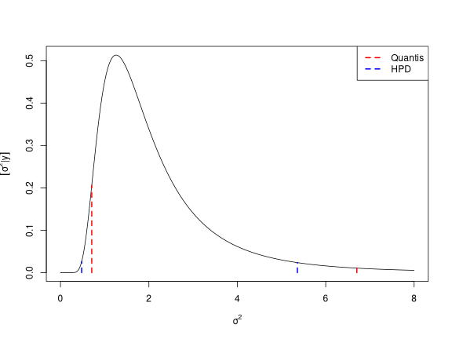

# Gráficos

### Priori, posteriori e verossimilhança

Para incluir o gráfico da **verossimilhança** na mesma escala
da priori e posteriori é necessário utilizar a função padronizada
(de forma a integrar 1).

Há duas formas que serão ilustradas a seguir:
1. reconhecendo o núcleo de alguma distribuição conhecida (quando
possível)
2. integrando explicitamente a verossimilhança (analítica ou
numericamente).

Neste exemplo a opção (1) é possível pois, para a verossimilhança,
tem-se que:
$$
L(\sigma^2|y) \propto
\text{IGama}(\alpha = (n/2)-1, \beta = 2/\sum_{i=1}^n(y_i-\mu)^2)
$$

# Gráficos

### Priori, posteriori e verossimilhança

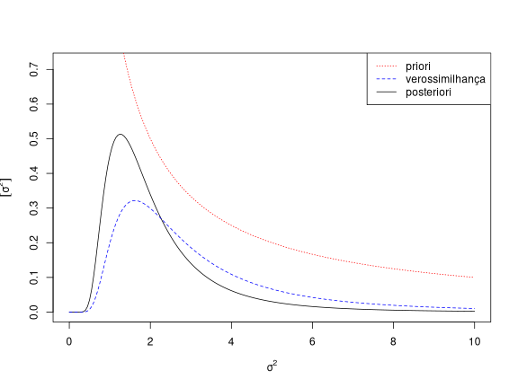